# PROJECT

## Import all relevant libraries here

```python
#0. import all necessary libraries
import pandas as pd
import matplotlib.pyplot as plt
import seaborn as sns
from sklearn.cluster import KMeans
from sklearn.preprocessing import StandardScaler
from sklearn.metrics import accuracy_score
from sklearn.metrics.cluster import adjusted_rand_score
from sklearn.neighbors import KNeighborsClassifier
import scipy.cluster.hierarchy as sch
from sklearn.cluster import AgglomerativeClustering
from sklearn.neighbors import NearestCentroid
pd.options.mode.chained_assignment = None
import warnings
warnings.filterwarnings('ignore')
sns.set()
```

## Part 1: Initialization

##### 1. [Download and] import the required dataset file into Jupyter notebook - 2 marks

##### 2. Display the first 10 rows on the dataset - 1 mark

```python
#1. read the dataset (in CSV format) into a python dataframe using pandas
df = pd.read_csv('dataset.csv')

#2. preview the data
df.head(10)
```

|  | Area | Perimeter | Compactness | Length | Width | Asymmetry | kernel_len | class |
| --- | --- | --- | --- | --- | --- | --- | --- | --- |
| 0 | 15.26 | 14.84 | 0.8710 | 5.763 | 3.312 | 2.221 | 5.220 | 1 |
| 1 | 14.88 | 14.57 | 0.8811 | 5.554 | 3.333 | 1.018 | 4.956 | 1 |
| 2 | 14.29 | 14.09 | 0.9050 | 5.291 | 3.337 | 2.699 | 4.825 | 1 |
| 3 | 13.84 | 13.94 | 0.8955 | 5.324 | 3.379 | 2.259 | 4.805 | 1 |
| 4 | 16.14 | 14.99 | 0.9034 | 5.658 | 3.562 | 1.355 | 5.175 | 1 |
| 5 | 14.38 | 14.21 | 0.8951 | 5.386 | 3.312 | 2.462 | 4.956 | 1 |
| 6 | 14.69 | 14.49 | 0.8799 | 5.563 | 3.259 | 3.586 | 5.219 | 1 |
| 7 | 14.11 | 14.10 | 0.8911 | 5.420 | 3.302 | 2.700 | 5.000 | 1 |
| 8 | 16.63 | 15.46 | 0.8747 | 6.053 | 3.465 | 2.040 | 5.877 | 1 |
| 9 | 16.44 | 15.25 | 0.8880 | 5.884 | 3.505 | 1.969 | 5.533 | 1 |

## let Y be the label and X all other columns

##### 3. Set Y as the “class” column and X as all other columns - 5 marks

```python
X = df.drop("class", axis=1)
Y = df[['class']]
```

##### 4. In Y, replace all 1 with 0, 2 with 1 and 3 with 2 - please follow this order when replacing to avoid errors later - 2 marks

```python
Y.replace({ 1 : 0, 2 : 1, 3 : 2 }, inplace=True)
```

```python
Y.value_counts()
```

```
class
0        70
1        70
2        70
dtype: int64
```

##### 5. Use a scatter plot to show "Area" (x-axis) vs "Perimeter" (y-axis) - 2 marks

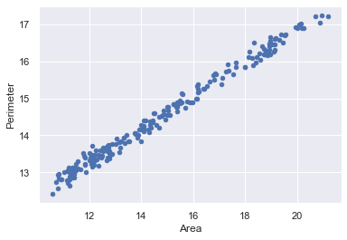

```python
#plot Area vs Perimeter
df.plot(kind = 'scatter', x = 'Area', y = 'Perimeter', c = 'b')
```

##### 6. Scale the dataset using StandardScaler - 3 marks

```python
scale = StandardScaler()
X_scaled = scale.fit_transform(X)
print(X_scaled)
```

```
[[ 1.42097769e-01  2.15462437e-01  6.06017918e-05 ...  1.41701823e-01
  -9.86151745e-01 -3.83577423e-01]
 [ 1.11880257e-02  8.22375713e-03  4.28515270e-01 ...  1.97432229e-01
  -1.78816620e+00 -9.22013487e-01]
 [-1.92066576e-01 -3.60200562e-01  1.44238325e+00 ...  2.08047544e-01
  -6.67479334e-01 -1.18919199e+00]
 ...
 [-5.67570840e-01 -6.90247348e-01  7.33948301e-01 ... -7.06044846e-02
   3.07658816e+00 -7.18060432e-01]
 [-1.03608992e+00 -1.03564515e+00 -8.01701104e-01 ... -1.12152071e+00
  -6.81351965e-02 -7.42534799e-01]
 [-8.77620233e-01 -9.35863561e-01 -1.10234659e-01 ... -7.55292327e-01
   1.29122264e+00 -7.03783718e-01]]
```

## Part 2: KMeans

#### 1. Use K-Means Elbow method to determine the number of clusters in dataset -

##### ii. Show your Elbow graph 5 marks

```python
distortions = []
K = range(1,10)
for k in K:
    kmeanModel = KMeans(n_clusters=k)
    kmeanModel.fit(X_scaled)
    distortions.append(kmeanModel.inertia_)
```

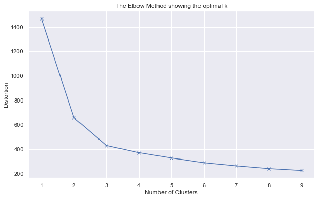

```python
plt.figure(figsize=(10,6))
plt.plot(K, distortions, 'bx-')
plt.xlabel('Number of Clusters')
plt.ylabel('Distortion')
plt.title('The Elbow Method showing the optimal k')
plt.show()
```

#### iii. Repeat KMeans but let k = the number of clusters which you selected from your Elbow graph in 2a above

```python
# k means
kmeans = KMeans(n_clusters=3, random_state=0)
df['cluster'] = kmeans.fit_predict(X_scaled)
```

```python
# get centroids
centroids = kmeans.cluster_centers_
cen_x = [i[0] for i in centroids]
cen_y = [i[1] for i in centroids]
## add to df
df['cen_x'] = df.cluster.map({0:cen_x[0], 1:cen_x[1], 2:cen_x[2]})
df['cen_y'] = df.cluster.map({0:cen_y[0], 1:cen_y[1], 2:cen_y[2]})
# define and map colors
colors = ['#DF2020', '#81DF20', '#2095DF']
df['c'] = df.cluster.map({0:colors[0], 1:colors[1], 2:colors[2]})
```

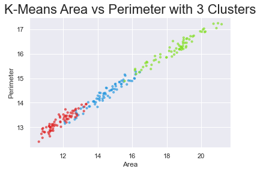

```python
plt.scatter(df.Area, df.Perimeter, c=df.c, alpha = 0.6, s=10)
# title and labels
plt.title('K-Means Area vs Perimeter with 3 Clusters', fontsize=22)
plt.xlabel('Area')
plt.ylabel('Perimeter')
```

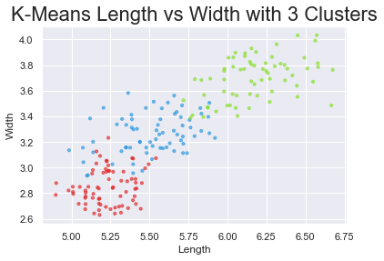

```python
plt.scatter(df.Length, df.Width, c=df.c, alpha = 0.6, s=10)
# title and labels
plt.title('K-Means Length vs Width with 3 Clusters', fontsize=22)
plt.xlabel('Length')
plt.ylabel('Width')
```

```python
# k means
kmeans = KMeans(n_clusters=2, random_state=0)
df['cluster2'] = kmeans.fit_predict(X_scaled)
```

```python
# get centroids
centroids = kmeans.cluster_centers_
cen_x = [i[0] for i in centroids]
cen_y = [i[1] for i in centroids]
## add to df
df['cen_x2'] = df.cluster2.map({0:cen_x[0], 1:cen_x[1]})
df['cen_y2'] = df.cluster2.map({0:cen_y[0], 1:cen_y[1]})
# define and map colors
colors = ['#DF2020', '#81DF20']
df['c2'] = df.cluster2.map({0:colors[0], 1:colors[1]})
```

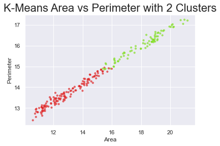

```python
plt.scatter(df.Area, df.Perimeter, c=df.c2, alpha = 0.6, s=10)
# title and labels
plt.title('K-Means Area vs Perimeter with 2 Clusters', fontsize=22)
plt.xlabel('Area')
plt.ylabel('Perimeter')
```

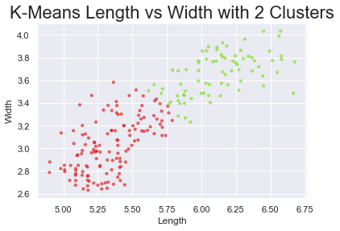

```python
plt.scatter(df.Length, df.Width, c=df.c2, alpha = 0.6, s=10)
# title and labels
plt.title('K-Means Length vs Width with 2 Clusters', fontsize=22)
plt.xlabel('Length')
plt.ylabel('Width')
```

### Calculate Accuracies of KMeans

#### 3. Calculate the classification accuracy of KMeans by comparing the output of KMeans in 2Bi above with the original labels of the dataset Y. 4 marks

```python
Y_1 = Y.values.flatten() # Converting label to 1D array
```

```python
score_kmeans = adjusted_rand_score(Y_1, df['cluster'])
```

```python
print(round(score_kmeans,2)*100)
```

```
77.0
```

## Part 3: AHC

#### 1. Use AHC dendrogram to determine the number of clusters in the dataset (set method = 'Ward') - 7.5 marks

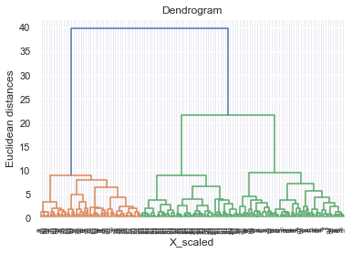

```python
dendrogram = sch.dendrogram(sch.linkage(X_scaled, method  = "ward"))
plt.title('Dendrogram')
plt.xlabel('X_scaled')
plt.ylabel('Euclidean distances')
plt.show()
```

##### 2. Perform AHC clustering with 3 clusters. - 7.5 marks

```python
hc = AgglomerativeClustering(n_clusters = 3, affinity = 'euclidean', linkage ='ward')
```

```python
df['y_hc'] = hc.fit_predict(X_scaled)
```

```python
# get centroids
clf = NearestCentroid()
clf.fit(X_scaled, df['y_hc'])
centroids = clf.centroids_
cen_x = [i[0] for i in centroids]
cen_y = [i[1] for i in centroids]
## add to df
df['cen_x_hc'] = df.y_hc.map({0:cen_x[0], 1:cen_x[1], 2:cen_x[2]})
df['cen_y_hc'] = df.y_hc.map({0:cen_y[0], 1:cen_y[1], 2:cen_y[2]})
# define and map colors
colors = ['#DF2020', '#81DF20', '#2095DF']
df['c_hc'] = df.y_hc.map({0:colors[0], 1:colors[1], 2:colors[2]})
```

##### 3. Plot a scatter plot for "Length" and "Width" clusters - 5 marks

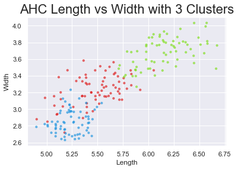

```python
plt.scatter(df.Length, df.Width, c=df.c_hc, alpha = 0.6, s=10)
# title and labels
plt.title('AHC Length vs Width with 3 Clusters', fontsize=22)
plt.xlabel('Length')
plt.ylabel('Width')
```

##### 4. Calculate the classification accuracy by comparing the output of AHC in B above with the original labels of the dataset Y. - 5 marks

```python
score_ahc = adjusted_rand_score(Y_1, df['y_hc'])
print(round(score_ahc,2)*100)
```

```
80.0
```

## Part 4: KNN

##### 1. Perform KNN clustering with Neighbour size of 3. - 7.5 marks

```python
#cluster the dataset using KNN and k = 3

# Create KNN classifier
knn = KNeighborsClassifier(n_neighbors = 3)
# Fit the classifier to the data
knn.fit(X_scaled,Y)
```

```
KNeighborsClassifier(n_neighbors=3)
```

##### 2. Plot a scatter plot for "Length" and "Width" clusters - 5 marks

```python
df['knn'] = knn.predict(X_scaled)
```

```python
# get centroids
clf = NearestCentroid()
clf.fit(X_scaled, df['knn'])
centroids = clf.centroids_
cen_x = [i[0] for i in centroids]
cen_y = [i[1] for i in centroids]
## add to df
df['cen_x_knn'] = df.knn.map({0:cen_x[0], 1:cen_x[1], 2:cen_x[2]})
df['cen_y_knn'] = df.knn.map({0:cen_y[0], 1:cen_y[1], 2:cen_y[2]})
# define and map colors
colors = ['#DF2020', '#81DF20', '#2095DF']
df['c_knn'] = df.knn.map({0:colors[0], 1:colors[1], 2:colors[2]})
```

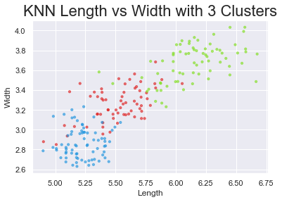

```python
plt.scatter(df.Length, df.Width, c=df.c_knn, alpha = 0.6, s=10)
# title and labels
plt.title('KNN Length vs Width with 3 Clusters', fontsize=22)
plt.xlabel('Length')
plt.ylabel('Width')
```

##### 3. Calculate the classification accuracy of KNN by comparing the output of KNN in A above with the original labels of the dataset Y. 5 marks

```python
#Results - compare prediction results with known values of Y
score_knn = adjusted_rand_score(Y_1, df['knn'])
round(score_knn*100,2)
```

```
93.01
```

##### 4. Using the output of KNN in A above and the original Y, draw a confusion matrix for KNN. - 7.5 marks

```python
#draw a confusion matrix of KNN
from sklearn.metrics import plot_confusion_matrix
```

[output not shown]

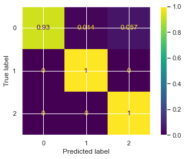

```python
plot_confusion_matrix(knn,X_scaled,Y,normalize='true')
```

## Part 5: Exit

##### 1. Draw a bar chart comparing the accuracies of KMeans, AHC and KNN when cluster size is set to 3.

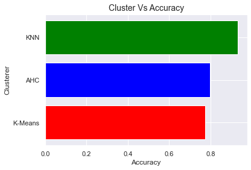

```python
Clusterer = ['K-Means','AHC','KNN']
Accuracy = [score_kmeans,score_ahc,score_knn]
Colors = ['red','blue','green']
plt.barh(Clusterer, Accuracy, color = Colors)
plt.title('Cluster Vs Accuracy', fontsize=14)
plt.ylabel('Clusterer')
plt.xlabel('Accuracy')
plt.grid(True)
plt.show()
```